# NBA Predictions

Comparing my models against 538 and some super-simple benchmarks

### Table of Contents

Each day I challenge [FiveThirtyEight’s Raptor](https://projects.fivethirtyeight.com/2020-nba-predictions/games/) predictions[^1].

## Today and Tomorrow’s Games

| game | elo | carm-elo | raptor | v01 | v02 |
| --- | --- | --- | --- | --- | --- |
| **Mon, Jan 27** |  |  |  |  |  |
| CLE @ DET | 80% | 81% | 69% | 72% | 70% |
| ORL @ MIA | 76% | 80% | 66% | 67% | 66% |
| SAS @ CHI | 46% | 50% | 57% | 68% | 55% |
| SAC @ MIN | 57% | 58% | 70% | 52% | 64% |
| DAL @ OKC | 63% | 65% | 48% | 54% | 49% |
| HOU @ UTA | 72% | 78% | 68% | 67% | 67% |
| **Tue, Jan 28** |  |  |  |  |  |
| NYK @ CHO | 67% | 69% | 63% | 56% | 54% |
| GSW @ PHI | 89% | 89% | 89% | 87% | 85% |
| NOP @ CLE | 34% | 27% | 26% | 58% | 51% |
| BOS @ MIA | 61% | 53% | 52% | 59% | 48% |
| ATL @ TOR | 92% | 93% | 88% | 60% | 69% |
| DEN @ MEM | 51% | 53% | 49% | 60% | 54% |
| WAS @ MIL | 94% | 94% | 89% | 69% | 74% |
| PHO @ DAL | 85% | 82% | 76% | 59% | 66% |
| LAC @ LAL | 67% | 67% | 73% | 65% | 57% |

## Last Three Day’s Predictions vs. Results

| date | team1 | team2 | result | elo | carm-elo | raptor | v01 | v02 |
| --- | --- | --- | --- | --- | --- | --- | --- | --- |
| 2020-01-24 | CHO | MIL | 0 | 0.099 | 0.089 | 0.083 | 0.245 | 0.224 |
| 2020-01-24 | DET | MEM | 0 | 0.595 | 0.581 | 0.409 | 0.518 | 0.617 |
| 2020-01-24 | ORL | BOS | 0 | 0.490 | 0.484 | 0.725 | 0.373 | 0.464 |
| 2020-01-24 | NYK | TOR | 0 | 0.208 | 0.166 | 0.193 | 0.246 | 0.316 |
| 2020-01-24 | CHI | SAC | 0 | 0.626 | 0.603 | 0.486 | 0.660 | 0.630 |
| 2020-01-24 | MIA | LAC | 0 | 0.625 | 0.620 | 0.399 | 0.604 | 0.516 |
| 2020-01-24 | MIN | HOU | 0 | 0.362 | 0.335 | 0.402 | 0.292 | 0.429 |
| 2020-01-24 | NOP | DEN | 0 | 0.511 | 0.512 | 0.660 | 0.355 | 0.480 |
| 2020-01-24 | OKC | ATL | 1 | 0.889 | 0.896 | 0.869 | 0.830 | 0.847 |
| 2020-01-24 | SAS | PHO | 0 | 0.798 | 0.822 | 0.607 | 0.655 | 0.615 |
| 2020-01-24 | GSW | IND | 0 | 0.322 | 0.328 | 0.407 | 0.244 | 0.283 |
| 2020-01-25 | UTA | DAL | 1 | 0.704 | 0.730 | 0.698 | 0.619 | 0.541 |
| 2020-01-25 | DET | BRK | 0 | 0.661 | 0.589 | 0.402 | 0.563 | 0.650 |
| 2020-01-25 | CLE | CHI | 0 | 0.517 | 0.584 | 0.679 | 0.535 | 0.460 |
| 2020-01-25 | MIN | OKC | 0 | 0.357 | 0.351 | 0.758 | 0.378 | 0.380 |
| 2020-01-25 | PHI | LAL | 1 | 0.540 | 0.519 | 0.509 | 0.479 | 0.451 |
| 2020-01-26 | DEN | HOU | NA | 0.625 | 0.637 | 0.501 | 0.586 | 0.575 |
| 2020-01-26 | SAS | TOR | NA | 0.440 | 0.432 | 0.364 | 0.361 | 0.434 |
| 2020-01-26 | ATL | WAS | NA | 0.530 | 0.521 | 0.493 | 0.558 | 0.507 |
| 2020-01-26 | MEM | PHO | NA | 0.748 | 0.769 | 0.591 | 0.644 | 0.548 |
| 2020-01-26 | NOP | BOS | NA | 0.437 | 0.410 | 0.712 | 0.324 | 0.391 |
| 2020-01-26 | NYK | BRK | NA | 0.491 | 0.518 | 0.626 | 0.552 | 0.545 |
| 2020-01-26 | ORL | LAC | NA | 0.473 | 0.468 | 0.591 | 0.366 | 0.353 |
| 2020-01-26 | POR | IND | NA | 0.474 | 0.476 | 0.663 | 0.390 | 0.401 |

## Seasonal Model Accuracy

This section compares how accurate my models are with FiveThirtyEight’s.

#### Up to Today

[output not shown]

- Win Rate: How often does the home team win?
- Home %: How often does the home team win when its win % before the game was more than 50%? (A home team with a record of 53% is predicted to win, butwith a record of 49% is predicted to lose.)
- Home % > Away %: If the home team’s win % is greater than away team’s win %, the home team is predicted to win. Otherwise, they’re predicted to lose. E.g., if home win % = 0.39 and away win% = 0.40, I predict the away team will win.
- v01: I build my own model.
- V02: Version 2 of my model.

#### Model Calibration

How well do the model’s predictions align with true probabilities? A prediction of 70% should win 70% of the time.

| score_range | home_winpct | v01 | v02 | elo | carm-elo | raptor |
| --- | --- | --- | --- | --- | --- | --- |
| all | 0.637 | 0.655 | 0.667 | 0.671 | 0.671 | 0.654 |
| 0.0:0.1 | NA | NA | NA | 0.000 | 0.000 | 0.000 |
| 0.1:0.2 | 0.520 | NA | NA | 0.000 | 0.000 | 0.286 |
| 0.2:0.3 | 0.296 | 0.154 | 0.182 | 0.167 | 0.382 | 0.256 |
| 0.3:0.4 | 0.424 | 0.298 | 0.288 | 0.295 | 0.279 | 0.236 |
| 0.4:0.5 | 0.435 | 0.419 | 0.376 | 0.337 | 0.365 | 0.411 |
| 0.5:0.6 | 0.581 | 0.506 | 0.497 | 0.486 | 0.546 | 0.443 |
| 0.6:0.7 | 0.765 | 0.620 | 0.655 | 0.612 | 0.567 | 0.568 |
| 0.7:0.8 | 0.688 | 0.692 | 0.716 | 0.670 | 0.661 | 0.611 |
| 0.8:0.9 | 0.839 | 0.913 | 0.895 | 0.771 | 0.729 | 0.836 |
| 0.9:1.0 | 0.500 | NA | NA | 0.958 | 0.930 | 0.865 |

#### Model Accuracy By Week

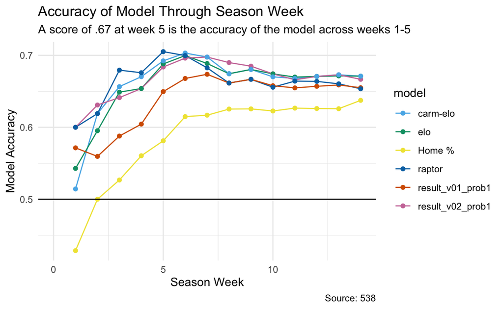

[^1]: FiveThirtyEight’s predictions are updated daily and can be downloaded here: https://projects.fivethirtyeight.com/nba-model/nba_elo_latest.csv.